# Risk Factor Analysis

## Outcome Variable

**Outcome Variable:** ever_stunted

## Predictor Variables

**Intervention Variable:** parity

**Adjustment Set:**

- arm
- W_mage
- meducyrs
- feducyrs
- hhwealth_quart
- W_mhtcm
- W_mwtkg
- W_mbmi
- vagbrth
- W_nrooms
- impsan
- delta_W_mage
- delta_meducyrs
- delta_feducyrs
- delta_hhwealth_quart
- delta_W_mhtcm
- delta_W_mwtkg
- delta_W_mbmi
- delta_vagbrth
- delta_W_nrooms
- delta_impsan

## Stratifying Variables

The analysis was stratified on these variable(s):

- agecat
- studyid
- country

## Data Summary

| agecat | studyid | country | parity | ever_stunted | n_cell | n |
| --- | --- | --- | --- | --- | --- | --- |
| 0-24 months | ki1000304b-SAS-CompFeed | INDIA | 1 | 0 | 162 | 1533 |
| 0-24 months | ki1000304b-SAS-CompFeed | INDIA | 1 | 1 | 290 | 1533 |
| 0-24 months | ki1000304b-SAS-CompFeed | INDIA | 2 | 0 | 122 | 1533 |
| 0-24 months | ki1000304b-SAS-CompFeed | INDIA | 2 | 1 | 238 | 1533 |
| 0-24 months | ki1000304b-SAS-CompFeed | INDIA | 3+ | 0 | 189 | 1533 |
| 0-24 months | ki1000304b-SAS-CompFeed | INDIA | 3+ | 1 | 532 | 1533 |
| 0-24 months | ki1000304b-SAS-FoodSuppl | INDIA | 1 | 0 | 13 | 418 |
| 0-24 months | ki1000304b-SAS-FoodSuppl | INDIA | 1 | 1 | 8 | 418 |
| 0-24 months | ki1000304b-SAS-FoodSuppl | INDIA | 2 | 0 | 19 | 418 |
| 0-24 months | ki1000304b-SAS-FoodSuppl | INDIA | 2 | 1 | 58 | 418 |
| 0-24 months | ki1000304b-SAS-FoodSuppl | INDIA | 3+ | 0 | 40 | 418 |
| 0-24 months | ki1000304b-SAS-FoodSuppl | INDIA | 3+ | 1 | 280 | 418 |
| 0-24 months | ki1017093b-PROVIDE | BANGLADESH | 1 | 0 | 154 | 700 |
| 0-24 months | ki1017093b-PROVIDE | BANGLADESH | 1 | 1 | 117 | 700 |
| 0-24 months | ki1017093b-PROVIDE | BANGLADESH | 2 | 0 | 134 | 700 |
| 0-24 months | ki1017093b-PROVIDE | BANGLADESH | 2 | 1 | 110 | 700 |
| 0-24 months | ki1017093b-PROVIDE | BANGLADESH | 3+ | 0 | 107 | 700 |
| 0-24 months | ki1017093b-PROVIDE | BANGLADESH | 3+ | 1 | 78 | 700 |
| 0-24 months | ki1066203-TanzaniaChild2 | TANZANIA, UNITED REPUBLIC OF | 1 | 0 | 550 | 2357 |
| 0-24 months | ki1066203-TanzaniaChild2 | TANZANIA, UNITED REPUBLIC OF | 1 | 1 | 271 | 2357 |
| 0-24 months | ki1066203-TanzaniaChild2 | TANZANIA, UNITED REPUBLIC OF | 2 | 0 | 494 | 2357 |
| 0-24 months | ki1066203-TanzaniaChild2 | TANZANIA, UNITED REPUBLIC OF | 2 | 1 | 277 | 2357 |
| 0-24 months | ki1066203-TanzaniaChild2 | TANZANIA, UNITED REPUBLIC OF | 3+ | 0 | 495 | 2357 |
| 0-24 months | ki1066203-TanzaniaChild2 | TANZANIA, UNITED REPUBLIC OF | 3+ | 1 | 270 | 2357 |
| 0-24 months | ki1101329-Keneba | GAMBIA | 1 | 0 | 119 | 1990 |
| 0-24 months | ki1101329-Keneba | GAMBIA | 1 | 1 | 122 | 1990 |
| 0-24 months | ki1101329-Keneba | GAMBIA | 2 | 0 | 110 | 1990 |
| 0-24 months | ki1101329-Keneba | GAMBIA | 2 | 1 | 104 | 1990 |
| 0-24 months | ki1101329-Keneba | GAMBIA | 3+ | 0 | 632 | 1990 |
| 0-24 months | ki1101329-Keneba | GAMBIA | 3+ | 1 | 903 | 1990 |

[output cut: 168 more lines]

The following strata were considered:

- agecat: 0-24 months, studyid: ki1000304b-SAS-CompFeed, country: INDIA
- agecat: 0-24 months, studyid: ki1000304b-SAS-FoodSuppl, country: INDIA
- agecat: 0-24 months, studyid: ki1017093b-PROVIDE, country: BANGLADESH
- agecat: 0-24 months, studyid: ki1066203-TanzaniaChild2, country: TANZANIA, UNITED REPUBLIC OF
- agecat: 0-24 months, studyid: ki1101329-Keneba, country: GAMBIA
- agecat: 0-24 months, studyid: ki1113344-GMS-Nepal, country: NEPAL
- agecat: 0-24 months, studyid: ki1126311-ZVITAMBO, country: ZIMBABWE
- agecat: 0-24 months, studyid: ki1135781-COHORTS, country: GUATEMALA
- agecat: 0-24 months, studyid: ki1135781-COHORTS, country: INDIA
- agecat: 0-24 months, studyid: ki1135781-COHORTS, country: PHILIPPINES
- agecat: 0-24 months, studyid: kiGH5241-JiVitA-3, country: BANGLADESH
- agecat: 0-6 months, studyid: ki1000304b-SAS-CompFeed, country: INDIA
- agecat: 0-6 months, studyid: ki1000304b-SAS-FoodSuppl, country: INDIA
- agecat: 0-6 months, studyid: ki1017093b-PROVIDE, country: BANGLADESH
- agecat: 0-6 months, studyid: ki1066203-TanzaniaChild2, country: TANZANIA, UNITED REPUBLIC OF
- agecat: 0-6 months, studyid: ki1101329-Keneba, country: GAMBIA
- agecat: 0-6 months, studyid: ki1113344-GMS-Nepal, country: NEPAL
- agecat: 0-6 months, studyid: ki1126311-ZVITAMBO, country: ZIMBABWE
- agecat: 0-6 months, studyid: ki1135781-COHORTS, country: GUATEMALA
- agecat: 0-6 months, studyid: ki1135781-COHORTS, country: INDIA
- agecat: 0-6 months, studyid: ki1135781-COHORTS, country: PHILIPPINES
- agecat: 0-6 months, studyid: kiGH5241-JiVitA-3, country: BANGLADESH
- agecat: 6-24 months, studyid: ki1000304b-SAS-CompFeed, country: INDIA
- agecat: 6-24 months, studyid: ki1000304b-SAS-FoodSuppl, country: INDIA
- agecat: 6-24 months, studyid: ki1017093b-PROVIDE, country: BANGLADESH
- agecat: 6-24 months, studyid: ki1066203-TanzaniaChild2, country: TANZANIA, UNITED REPUBLIC OF
- agecat: 6-24 months, studyid: ki1101329-Keneba, country: GAMBIA
- agecat: 6-24 months, studyid: ki1113344-GMS-Nepal, country: NEPAL
- agecat: 6-24 months, studyid: ki1126311-ZVITAMBO, country: ZIMBABWE
- agecat: 6-24 months, studyid: ki1135781-COHORTS, country: GUATEMALA
- agecat: 6-24 months, studyid: ki1135781-COHORTS, country: INDIA
- agecat: 6-24 months, studyid: ki1135781-COHORTS, country: PHILIPPINES
- agecat: 6-24 months, studyid: kiGH5241-JiVitA-3, country: BANGLADESH

### Dropped Strata

Some strata were dropped due to rare outcomes:

- agecat: 6-24 months, studyid: ki1000304b-SAS-FoodSuppl, country: INDIA

## Methods Detail

We’re interested in the causal parameters $E[Y_a]$ for all values of $a \in \mathcal{A}$. These parameters represent the mean outcome if, possibly contrary to fact, we intervened to set all units to have $A=a$. Under the randomization and positivity assumptions, these are identified by the statistical parameters $\psi_a=E_W[E_{Y|A,W}(Y|A=a,W)]$. In addition, we’re interested in the mean of $Y$, $E[Y]$ under no intervention (the observed mean). We will estimate these parameters by using SuperLearner to fit the relevant likelihood factors – $E_{Y|A,W}(Y|A=a,W)$ and $p(A=a|W)$, and then updating our likelihood fit using a joint TMLE.

For unadjusted analyses ($W=\{\}$), initial likelihoods were estimated using Lrnr_glm to estimate the simple $E(Y|A)$ and Lrnr_mean to estimate $p(A)$. For adjusted analyses, a small library containing Lrnr_glmnet, Lrnr_xgboost, and Lrnr_mean was used.

Having estimated these parameters, we will then use the delta method to estimate relative risks and attributable risks relative to a prespecified baseline level of $A$.

# Results Detail

## Results Plots

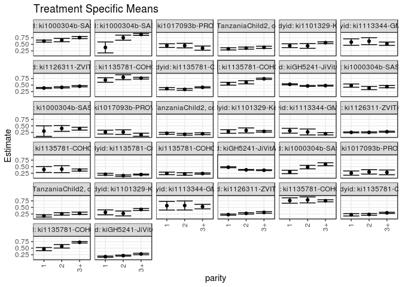

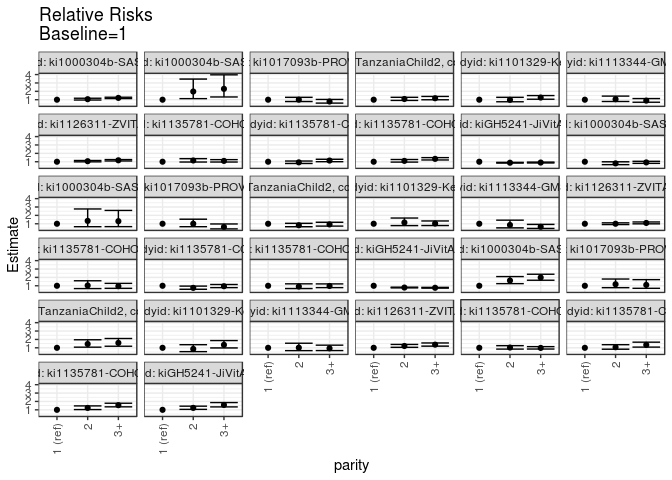

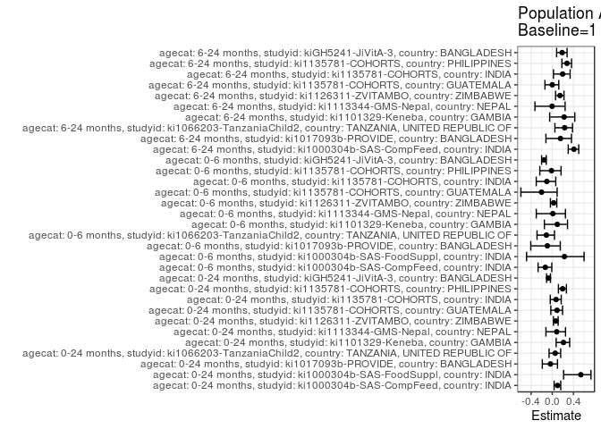

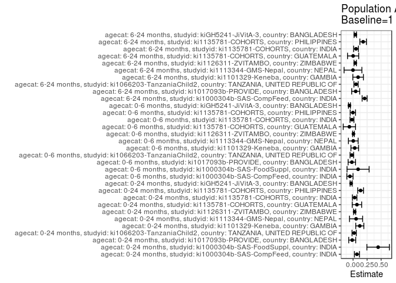

## Results Table

### Parameter: TSM

| agecat | studyid | country | intervention_level | baseline_level | estimate | ci_lower | ci_upper |
| --- | --- | --- | --- | --- | --- | --- | --- |
| 0-24 months | ki1000304b-SAS-CompFeed | INDIA | 1 | NA | 0.6225985 | 0.5829000 | 0.6622969 |
| 0-24 months | ki1000304b-SAS-CompFeed | INDIA | 2 | NA | 0.6616061 | 0.5983179 | 0.7248943 |
| 0-24 months | ki1000304b-SAS-CompFeed | INDIA | 3+ | NA | 0.7564748 | 0.7166316 | 0.7963180 |
| 0-24 months | ki1000304b-SAS-FoodSuppl | INDIA | 1 | NA | 0.3809524 | 0.1730038 | 0.5889009 |
| 0-24 months | ki1000304b-SAS-FoodSuppl | INDIA | 2 | NA | 0.7532468 | 0.6568366 | 0.8496569 |
| 0-24 months | ki1000304b-SAS-FoodSuppl | INDIA | 3+ | NA | 0.8750000 | 0.8387213 | 0.9112787 |
| 0-24 months | ki1017093b-PROVIDE | BANGLADESH | 1 | NA | 0.4509264 | 0.3798779 | 0.5219749 |
| 0-24 months | ki1017093b-PROVIDE | BANGLADESH | 2 | NA | 0.4518484 | 0.3643246 | 0.5393721 |
| 0-24 months | ki1017093b-PROVIDE | BANGLADESH | 3+ | NA | 0.3539573 | 0.2736940 | 0.4342206 |
| 0-24 months | ki1066203-TanzaniaChild2 | TANZANIA, UNITED REPUBLIC OF | 1 | NA | 0.3277390 | 0.2855801 | 0.3698979 |
| 0-24 months | ki1066203-TanzaniaChild2 | TANZANIA, UNITED REPUBLIC OF | 2 | NA | 0.3558185 | 0.3151429 | 0.3964940 |
| 0-24 months | ki1066203-TanzaniaChild2 | TANZANIA, UNITED REPUBLIC OF | 3+ | NA | 0.3848218 | 0.3420253 | 0.4276183 |
| 0-24 months | ki1101329-Keneba | GAMBIA | 1 | NA | 0.4475258 | 0.3743256 | 0.5207261 |
| 0-24 months | ki1101329-Keneba | GAMBIA | 2 | NA | 0.4406796 | 0.3485471 | 0.5328121 |
| 0-24 months | ki1101329-Keneba | GAMBIA | 3+ | NA | 0.5618541 | 0.5296533 | 0.5940549 |
| 0-24 months | ki1113344-GMS-Nepal | NEPAL | 1 | NA | 0.5853059 | 0.4622655 | 0.7083463 |
| 0-24 months | ki1113344-GMS-Nepal | NEPAL | 2 | NA | 0.6201237 | 0.4870721 | 0.7531753 |
| 0-24 months | ki1113344-GMS-Nepal | NEPAL | 3+ | NA | 0.5216873 | 0.4577191 | 0.5856555 |
| 0-24 months | ki1126311-ZVITAMBO | ZIMBABWE | 1 | NA | 0.3888538 | 0.3689372 | 0.4087705 |
| 0-24 months | ki1126311-ZVITAMBO | ZIMBABWE | 2 | NA | 0.4135726 | 0.3913980 | 0.4357472 |
| 0-24 months | ki1126311-ZVITAMBO | ZIMBABWE | 3+ | NA | 0.4555640 | 0.4318408 | 0.4792872 |
| 0-24 months | ki1135781-COHORTS | GUATEMALA | 1 | NA | 0.6951645 | 0.6076705 | 0.7826585 |
| 0-24 months | ki1135781-COHORTS | GUATEMALA | 2 | NA | 0.7991382 | 0.7040144 | 0.8942619 |
| 0-24 months | ki1135781-COHORTS | GUATEMALA | 3+ | NA | 0.7631460 | 0.7302031 | 0.7960890 |
| 0-24 months | ki1135781-COHORTS | INDIA | 1 | NA | 0.3631746 | 0.3208004 | 0.4055487 |
| 0-24 months | ki1135781-COHORTS | INDIA | 2 | NA | 0.3363384 | 0.3012668 | 0.3714100 |
| 0-24 months | ki1135781-COHORTS | INDIA | 3+ | NA | 0.4141405 | 0.3930376 | 0.4352433 |
| 0-24 months | ki1135781-COHORTS | PHILIPPINES | 1 | NA | 0.5523391 | 0.4979527 | 0.6067255 |
| 0-24 months | ki1135781-COHORTS | PHILIPPINES | 2 | NA | 0.6074446 | 0.5463282 | 0.6685610 |
| 0-24 months | ki1135781-COHORTS | PHILIPPINES | 3+ | NA | 0.7413078 | 0.7163508 | 0.7662647 |

[output cut: 66 more lines]

### Parameter: E(Y)

| agecat | studyid | country | intervention_level | baseline_level | estimate | ci_lower | ci_upper |
| --- | --- | --- | --- | --- | --- | --- | --- |
| 0-24 months | ki1000304b-SAS-CompFeed | INDIA | NA | NA | 0.6914547 | 0.6510509 | 0.7318584 |
| 0-24 months | ki1000304b-SAS-FoodSuppl | INDIA | NA | NA | 0.8277512 | 0.7915095 | 0.8639929 |
| 0-24 months | ki1017093b-PROVIDE | BANGLADESH | NA | NA | 0.4357143 | 0.3989556 | 0.4724730 |
| 0-24 months | ki1066203-TanzaniaChild2 | TANZANIA, UNITED REPUBLIC OF | NA | NA | 0.3470513 | 0.3278294 | 0.3662733 |
| 0-24 months | ki1101329-Keneba | GAMBIA | NA | NA | 0.5673367 | 0.5455633 | 0.5891101 |
| 0-24 months | ki1113344-GMS-Nepal | NEPAL | NA | NA | 0.6389685 | 0.6033115 | 0.6746254 |
| 0-24 months | ki1126311-ZVITAMBO | ZIMBABWE | NA | NA | 0.4171108 | 0.4089639 | 0.4252576 |
| 0-24 months | ki1135781-COHORTS | GUATEMALA | NA | NA | 0.7639706 | 0.7413939 | 0.7865473 |
| 0-24 months | ki1135781-COHORTS | INDIA | NA | NA | 0.3911447 | 0.3770865 | 0.4052029 |
| 0-24 months | ki1135781-COHORTS | PHILIPPINES | NA | NA | 0.6863963 | 0.6699497 | 0.7028430 |
| 0-24 months | kiGH5241-JiVitA-3 | BANGLADESH | NA | NA | 0.4953171 | 0.4874955 | 0.5031388 |
| 0-6 months | ki1000304b-SAS-CompFeed | INDIA | NA | NA | 0.4254902 | 0.3977202 | 0.4532601 |
| 0-6 months | ki1000304b-SAS-FoodSuppl | INDIA | NA | NA | 0.3894231 | 0.3425088 | 0.4363374 |
| 0-6 months | ki1017093b-PROVIDE | BANGLADESH | NA | NA | 0.2400000 | 0.2083392 | 0.2716608 |
| 0-6 months | ki1066203-TanzaniaChild2 | TANZANIA, UNITED REPUBLIC OF | NA | NA | 0.1947391 | 0.1787488 | 0.2107293 |
| 0-6 months | ki1101329-Keneba | GAMBIA | NA | NA | 0.3135456 | 0.2924164 | 0.3346748 |
| 0-6 months | ki1113344-GMS-Nepal | NEPAL | NA | NA | 0.3180516 | 0.2834770 | 0.3526261 |
| 0-6 months | ki1126311-ZVITAMBO | ZIMBABWE | NA | NA | 0.2586796 | 0.2514399 | 0.2659192 |
| 0-6 months | ki1135781-COHORTS | GUATEMALA | NA | NA | 0.3253896 | 0.2975756 | 0.3532035 |
| 0-6 months | ki1135781-COHORTS | INDIA | NA | NA | 0.1902526 | 0.1787489 | 0.2017563 |
| 0-6 months | ki1135781-COHORTS | PHILIPPINES | NA | NA | 0.2390451 | 0.2239262 | 0.2541640 |
| 0-6 months | kiGH5241-JiVitA-3 | BANGLADESH | NA | NA | 0.4129818 | 0.4055453 | 0.4204184 |
| 6-24 months | ki1000304b-SAS-CompFeed | INDIA | NA | NA | 0.5030750 | 0.4588491 | 0.5473009 |
| 6-24 months | ki1017093b-PROVIDE | BANGLADESH | NA | NA | 0.3004386 | 0.2583143 | 0.3425629 |
| 6-24 months | ki1066203-TanzaniaChild2 | TANZANIA, UNITED REPUBLIC OF | NA | NA | 0.2276474 | 0.2069456 | 0.2483493 |
| 6-24 months | ki1101329-Keneba | GAMBIA | NA | NA | 0.4014652 | 0.3754511 | 0.4274793 |
| 6-24 months | ki1113344-GMS-Nepal | NEPAL | NA | NA | 0.5642317 | 0.5153938 | 0.6130696 |
| 6-24 months | ki1126311-ZVITAMBO | ZIMBABWE | NA | NA | 0.2629473 | 0.2535857 | 0.2723089 |
| 6-24 months | ki1135781-COHORTS | GUATEMALA | NA | NA | 0.7642458 | 0.7364214 | 0.7920702 |
| 6-24 months | ki1135781-COHORTS | INDIA | NA | NA | 0.2705750 | 0.2559548 | 0.2851951 |
| 6-24 months | ki1135781-COHORTS | PHILIPPINES | NA | NA | 0.6449788 | 0.6246093 | 0.6653483 |
| 6-24 months | kiGH5241-JiVitA-3 | BANGLADESH | NA | NA | 0.2162394 | 0.2068628 | 0.2256160 |

### Parameter: RR

| agecat | studyid | country | intervention_level | baseline_level | estimate | ci_lower | ci_upper |
| --- | --- | --- | --- | --- | --- | --- | --- |
| 0-24 months | ki1000304b-SAS-CompFeed | INDIA | 1 | 1 | 1.0000000 | 1.0000000 | 1.0000000 |
| 0-24 months | ki1000304b-SAS-CompFeed | INDIA | 2 | 1 | 1.0626529 | 0.9611416 | 1.1748853 |
| 0-24 months | ki1000304b-SAS-CompFeed | INDIA | 3+ | 1 | 1.2150283 | 1.1377893 | 1.2975108 |
| 0-24 months | ki1000304b-SAS-FoodSuppl | INDIA | 1 | 1 | 1.0000000 | 1.0000000 | 1.0000000 |
| 0-24 months | ki1000304b-SAS-FoodSuppl | INDIA | 2 | 1 | 1.9772727 | 1.1286797 | 3.4638767 |
| 0-24 months | ki1000304b-SAS-FoodSuppl | INDIA | 3+ | 1 | 2.2968750 | 1.3285819 | 3.9708764 |
| 0-24 months | ki1017093b-PROVIDE | BANGLADESH | 1 | 1 | 1.0000000 | 1.0000000 | 1.0000000 |
| 0-24 months | ki1017093b-PROVIDE | BANGLADESH | 2 | 1 | 1.0020446 | 0.7825028 | 1.2831818 |
| 0-24 months | ki1017093b-PROVIDE | BANGLADESH | 3+ | 1 | 0.7849558 | 0.5975267 | 1.0311768 |
| 0-24 months | ki1066203-TanzaniaChild2 | TANZANIA, UNITED REPUBLIC OF | 1 | 1 | 1.0000000 | 1.0000000 | 1.0000000 |
| 0-24 months | ki1066203-TanzaniaChild2 | TANZANIA, UNITED REPUBLIC OF | 2 | 1 | 1.0856763 | 0.9146116 | 1.2887361 |
| 0-24 months | ki1066203-TanzaniaChild2 | TANZANIA, UNITED REPUBLIC OF | 3+ | 1 | 1.1741715 | 0.9909819 | 1.3912249 |
| 0-24 months | ki1101329-Keneba | GAMBIA | 1 | 1 | 1.0000000 | 1.0000000 | 1.0000000 |
| 0-24 months | ki1101329-Keneba | GAMBIA | 2 | 1 | 0.9847020 | 0.7554425 | 1.2835365 |
| 0-24 months | ki1101329-Keneba | GAMBIA | 3+ | 1 | 1.2554674 | 1.0558730 | 1.4927916 |
| 0-24 months | ki1113344-GMS-Nepal | NEPAL | 1 | 1 | 1.0000000 | 1.0000000 | 1.0000000 |
| 0-24 months | ki1113344-GMS-Nepal | NEPAL | 2 | 1 | 1.0594864 | 0.7848076 | 1.4303015 |
| 0-24 months | ki1113344-GMS-Nepal | NEPAL | 3+ | 1 | 0.8913071 | 0.6982748 | 1.1377015 |
| 0-24 months | ki1126311-ZVITAMBO | ZIMBABWE | 1 | 1 | 1.0000000 | 1.0000000 | 1.0000000 |
| 0-24 months | ki1126311-ZVITAMBO | ZIMBABWE | 2 | 1 | 1.0635682 | 0.9878211 | 1.1451237 |
| 0-24 months | ki1126311-ZVITAMBO | ZIMBABWE | 3+ | 1 | 1.1715559 | 1.0893448 | 1.2599712 |
| 0-24 months | ki1135781-COHORTS | GUATEMALA | 1 | 1 | 1.0000000 | 1.0000000 | 1.0000000 |
| 0-24 months | ki1135781-COHORTS | GUATEMALA | 2 | 1 | 1.1495670 | 0.9670009 | 1.3666010 |
| 0-24 months | ki1135781-COHORTS | GUATEMALA | 3+ | 1 | 1.0977920 | 0.9618550 | 1.2529408 |
| 0-24 months | ki1135781-COHORTS | INDIA | 1 | 1 | 1.0000000 | 1.0000000 | 1.0000000 |
| 0-24 months | ki1135781-COHORTS | INDIA | 2 | 1 | 0.9261066 | 0.7922613 | 1.0825639 |
| 0-24 months | ki1135781-COHORTS | INDIA | 3+ | 1 | 1.1403344 | 1.0044051 | 1.2946595 |
| 0-24 months | ki1135781-COHORTS | PHILIPPINES | 1 | 1 | 1.0000000 | 1.0000000 | 1.0000000 |
| 0-24 months | ki1135781-COHORTS | PHILIPPINES | 2 | 1 | 1.0997675 | 0.9557370 | 1.2655035 |
| 0-24 months | ki1135781-COHORTS | PHILIPPINES | 3+ | 1 | 1.3421243 | 1.2097340 | 1.4890031 |

[output cut: 66 more lines]

### Parameter: PAR

| agecat | studyid | country | intervention_level | baseline_level | estimate | ci_lower | ci_upper |
| --- | --- | --- | --- | --- | --- | --- | --- |
| 0-24 months | ki1000304b-SAS-CompFeed | INDIA | 1 | NA | 0.0688562 | 0.0238949 | 0.1138174 |
| 0-24 months | ki1000304b-SAS-FoodSuppl | INDIA | 1 | NA | 0.4467988 | 0.2462717 | 0.6473259 |
| 0-24 months | ki1017093b-PROVIDE | BANGLADESH | 1 | NA | -0.0152121 | -0.0773351 | 0.0469109 |
| 0-24 months | ki1066203-TanzaniaChild2 | TANZANIA, UNITED REPUBLIC OF | 1 | NA | 0.0193123 | -0.0185237 | 0.0571484 |
| 0-24 months | ki1101329-Keneba | GAMBIA | 1 | NA | 0.1198108 | 0.0475010 | 0.1921207 |
| 0-24 months | ki1113344-GMS-Nepal | NEPAL | 1 | NA | 0.0536626 | -0.0634400 | 0.1707651 |
| 0-24 months | ki1126311-ZVITAMBO | ZIMBABWE | 1 | NA | 0.0282569 | 0.0099573 | 0.0465566 |
| 0-24 months | ki1135781-COHORTS | GUATEMALA | 1 | NA | 0.0688061 | -0.0154681 | 0.1530804 |
| 0-24 months | ki1135781-COHORTS | INDIA | 1 | NA | 0.0279701 | -0.0123904 | 0.0683306 |
| 0-24 months | ki1135781-COHORTS | PHILIPPINES | 1 | NA | 0.1340572 | 0.0824913 | 0.1856232 |
| 0-24 months | kiGH5241-JiVitA-3 | BANGLADESH | 1 | NA | -0.0346876 | -0.0528047 | -0.0165705 |
| 0-6 months | ki1000304b-SAS-CompFeed | INDIA | 1 | NA | -0.0557090 | -0.1105010 | -0.0009170 |
| 0-6 months | ki1000304b-SAS-FoodSuppl | INDIA | 1 | NA | 0.0894231 | -0.1074162 | 0.2862624 |
| 0-6 months | ki1017093b-PROVIDE | BANGLADESH | 1 | NA | -0.0220996 | -0.0882484 | 0.0440492 |
| 0-6 months | ki1066203-TanzaniaChild2 | TANZANIA, UNITED REPUBLIC OF | 1 | NA | -0.0216138 | -0.0535470 | 0.0103195 |
| 0-6 months | ki1101329-Keneba | GAMBIA | 1 | NA | 0.0298879 | -0.0381971 | 0.0979729 |
| 0-6 months | ki1113344-GMS-Nepal | NEPAL | 1 | NA | 0.0034515 | -0.0829897 | 0.0898927 |
| 0-6 months | ki1126311-ZVITAMBO | ZIMBABWE | 1 | NA | 0.0070286 | -0.0085081 | 0.0225654 |
| 0-6 months | ki1135781-COHORTS | GUATEMALA | 1 | NA | -0.0657919 | -0.1753893 | 0.0438056 |
| 0-6 months | ki1135781-COHORTS | INDIA | 1 | NA | -0.0195933 | -0.0544873 | 0.0153007 |
| 0-6 months | ki1135781-COHORTS | PHILIPPINES | 1 | NA | -0.0035534 | -0.0511568 | 0.0440499 |
| 0-6 months | kiGH5241-JiVitA-3 | BANGLADESH | 1 | NA | -0.0646214 | -0.0826169 | -0.0466260 |
| 6-24 months | ki1000304b-SAS-CompFeed | INDIA | 1 | NA | 0.2057393 | 0.1615359 | 0.2499428 |
| 6-24 months | ki1017093b-PROVIDE | BANGLADESH | 1 | NA | 0.0466120 | -0.0249747 | 0.1181987 |
| 6-24 months | ki1066203-TanzaniaChild2 | TANZANIA, UNITED REPUBLIC OF | 1 | NA | 0.0532390 | 0.0155195 | 0.0909585 |
| 6-24 months | ki1101329-Keneba | GAMBIA | 1 | NA | 0.0897707 | -0.0044079 | 0.1839494 |
| 6-24 months | ki1113344-GMS-Nepal | NEPAL | 1 | NA | -0.0015011 | -0.1601376 | 0.1571353 |
| 6-24 months | ki1126311-ZVITAMBO | ZIMBABWE | 1 | NA | 0.0382336 | 0.0173172 | 0.0591500 |
| 6-24 months | ki1135781-COHORTS | GUATEMALA | 1 | NA | 0.0006496 | -0.0987391 | 0.1000383 |
| 6-24 months | ki1135781-COHORTS | INDIA | 1 | NA | 0.0527980 | 0.0104190 | 0.0951769 |
| 6-24 months | ki1135781-COHORTS | PHILIPPINES | 1 | NA | 0.1795312 | 0.1212069 | 0.2378554 |
| 6-24 months | kiGH5241-JiVitA-3 | BANGLADESH | 1 | NA | 0.0404204 | 0.0189846 | 0.0618562 |

### Parameter: PAF

| agecat | studyid | country | intervention_level | baseline_level | estimate | ci_lower | ci_upper |
| --- | --- | --- | --- | --- | --- | --- | --- |
| 0-24 months | ki1000304b-SAS-CompFeed | INDIA | 1 | NA | 0.0995816 | 0.0355253 | 0.1593836 |
| 0-24 months | ki1000304b-SAS-FoodSuppl | INDIA | 1 | NA | 0.5397743 | 0.2142753 | 0.7304301 |
| 0-24 months | ki1017093b-PROVIDE | BANGLADESH | 1 | NA | -0.0349130 | -0.1879339 | 0.0983968 |
| 0-24 months | ki1066203-TanzaniaChild2 | TANZANIA, UNITED REPUBLIC OF | 1 | NA | 0.0556469 | -0.0599096 | 0.1586048 |
| 0-24 months | ki1101329-Keneba | GAMBIA | 1 | NA | 0.2111812 | 0.0735925 | 0.3283354 |
| 0-24 months | ki1113344-GMS-Nepal | NEPAL | 1 | NA | 0.0839831 | -0.1190837 | 0.2502018 |
| 0-24 months | ki1126311-ZVITAMBO | ZIMBABWE | 1 | NA | 0.0677444 | 0.0228237 | 0.1106002 |
| 0-24 months | ki1135781-COHORTS | GUATEMALA | 1 | NA | 0.0900638 | -0.0272825 | 0.1940057 |
| 0-24 months | ki1135781-COHORTS | INDIA | 1 | NA | 0.0715084 | -0.0375865 | 0.1691327 |
| 0-24 months | ki1135781-COHORTS | PHILIPPINES | 1 | NA | 0.1953058 | 0.1163161 | 0.2672349 |
| 0-24 months | kiGH5241-JiVitA-3 | BANGLADESH | 1 | NA | -0.0700311 | -0.1072753 | -0.0340397 |
| 0-6 months | ki1000304b-SAS-CompFeed | INDIA | 1 | NA | -0.1309289 | -0.2676773 | -0.0089320 |
| 0-6 months | ki1000304b-SAS-FoodSuppl | INDIA | 1 | NA | 0.2296296 | -0.4847259 | 0.6002828 |
| 0-6 months | ki1017093b-PROVIDE | BANGLADESH | 1 | NA | -0.0920816 | -0.4057417 | 0.1515922 |
| 0-6 months | ki1066203-TanzaniaChild2 | TANZANIA, UNITED REPUBLIC OF | 1 | NA | -0.1109883 | -0.2876971 | 0.0414710 |
| 0-6 months | ki1101329-Keneba | GAMBIA | 1 | NA | 0.0953224 | -0.1492736 | 0.2878618 |
| 0-6 months | ki1113344-GMS-Nepal | NEPAL | 1 | NA | 0.0108520 | -0.3019223 | 0.2484853 |
| 0-6 months | ki1126311-ZVITAMBO | ZIMBABWE | 1 | NA | 0.0271713 | -0.0347763 | 0.0854103 |
| 0-6 months | ki1135781-COHORTS | GUATEMALA | 1 | NA | -0.2021941 | -0.5918263 | 0.0920676 |
| 0-6 months | ki1135781-COHORTS | INDIA | 1 | NA | -0.1029857 | -0.3025997 | 0.0660389 |
| 0-6 months | ki1135781-COHORTS | PHILIPPINES | 1 | NA | -0.0148651 | -0.2349108 | 0.1659711 |
| 0-6 months | kiGH5241-JiVitA-3 | BANGLADESH | 1 | NA | -0.1564753 | -0.2010065 | -0.1135952 |
| 6-24 months | ki1000304b-SAS-CompFeed | INDIA | 1 | NA | 0.4089635 | 0.3018996 | 0.4996076 |
| 6-24 months | ki1017093b-PROVIDE | BANGLADESH | 1 | NA | 0.1551466 | -0.1196293 | 0.3624879 |
| 6-24 months | ki1066203-TanzaniaChild2 | TANZANIA, UNITED REPUBLIC OF | 1 | NA | 0.2338660 | 0.0498138 | 0.3822671 |
| 6-24 months | ki1101329-Keneba | GAMBIA | 1 | NA | 0.2236078 | -0.0490340 | 0.4253905 |
| 6-24 months | ki1113344-GMS-Nepal | NEPAL | 1 | NA | -0.0026605 | -0.3271928 | 0.2425154 |
| 6-24 months | ki1126311-ZVITAMBO | ZIMBABWE | 1 | NA | 0.1454041 | 0.0621094 | 0.2213012 |
| 6-24 months | ki1135781-COHORTS | GUATEMALA | 1 | NA | 0.0008500 | -0.1380398 | 0.1227893 |
| 6-24 months | ki1135781-COHORTS | INDIA | 1 | NA | 0.1951325 | 0.0224859 | 0.3372866 |
| 6-24 months | ki1135781-COHORTS | PHILIPPINES | 1 | NA | 0.2783520 | 0.1816083 | 0.3636595 |
| 6-24 months | kiGH5241-JiVitA-3 | BANGLADESH | 1 | NA | 0.1869243 | 0.0821846 | 0.2797112 |